# Project 2

Philip Mateescu

September 22, 2015

```r
options(warnings=-1)
```

# Data

PM2.5 Emissions Data (summarySCC_PM25.rds): This file contains a data frame with all of the PM2.5 emissions data for 1999, 2002, 2005, and 2008. For each year, the table contains number of tons of PM2.5 emitted from a specific type of source for the entire year. Here are the first few rows.

```
##     fips      SCC Pollutant Emissions  type year
## 4  09001 10100401  PM25-PRI    15.714 POINT 1999
## 8  09001 10100404  PM25-PRI   234.178 POINT 1999
## 12 09001 10100501  PM25-PRI     0.128 POINT 1999
## 16 09001 10200401  PM25-PRI     2.036 POINT 1999
## 20 09001 10200504  PM25-PRI     0.388 POINT 1999
## 24 09001 10200602  PM25-PRI     1.490 POINT 1999
```

- fips: A five-digit number (represented as a string) indicating the U.S. county
- SCC: The name of the source as indicated by a digit string (see source code classification table)
- Pollutant: A string indicating the pollutant
- Emissions: Amount of PM2.5 emitted, in tons
- type: The type of source (point, non-point, on-road, or non-road)
- year: The year of emissions recorded

Source Classification Code Table (Source_Classification_Code.rds): This table provides a mapping from the SCC digit strings in the Emissions table to the actual name of the PM2.5 source. The sources are categorized in a few different ways from more general to more specific and you may choose to explore whatever categories you think are most useful. For example, source “10100101” is known as “Ext Comb /Electric Gen /Anthracite Coal /Pulverized Coal”.

You can read each of the two files using the readRDS() function in R.

```r
# might take a while
if (!exists('NEI')) {
    NEI <- readRDS('data/summarySCC_PM25.rds')
    SCC <- readRDS('data/Source_Classification_Code.rds')
}
```

# Assignment

The overall goal of this assignment is to explore the National Emissions Inventory database and see what it say about fine particulate matter pollution in the United states over the 10-year period 1999–2008. You may use any R package you want to support your analysis.

## Questions

You must address the following questions and tasks in your exploratory analysis. For each question/task you will need to make a single plot. Unless specified, you can use any plotting system in R to make your plot.

### 1. Have total emissions from PM2.5 decreased in the United States from 1999 to 2008?

Using the **base** plotting system, make a plot showing the *total* PM2.5 emission from all sources for each of the years 1999, 2002, 2005, and 2008.

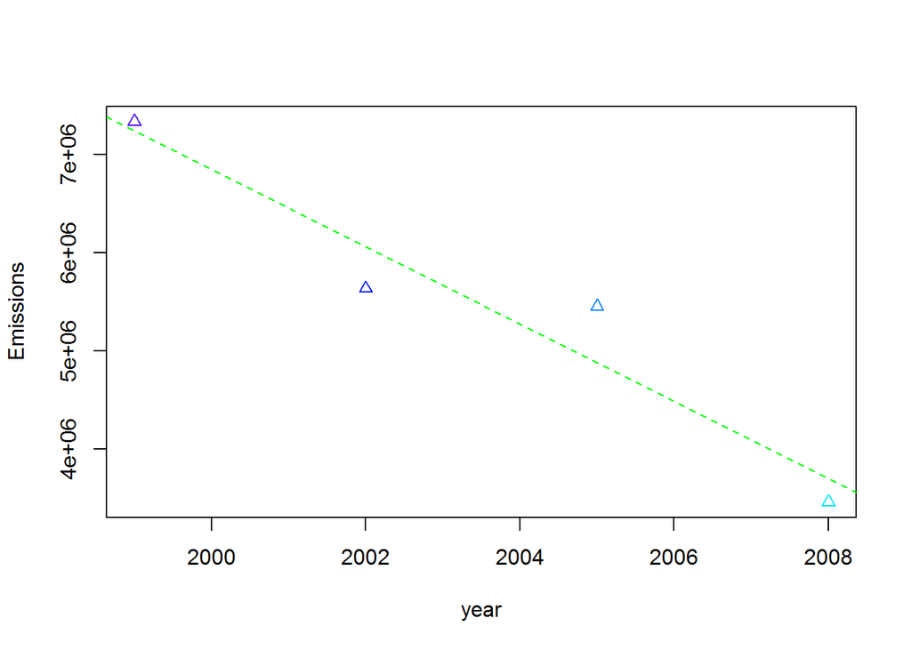

```r
# this might also take a bit
pm25.agg <- aggregate(Emissions ~ year, data=NEI, FUN=sum)
plot(Emissions ~ year, data = pm25.agg, pch=2, col=topo.colors(8))
# add a regression line
pm25.agg.regr <- lm(Emissions ~ year, pm25.agg)
# width=1, dotted, green
abline(pm25.agg.regr, lwd=1, lty=2, col='green')
```

### 2. Have total emissions from PM2.5 decreased in the Baltimore City, Maryland (fips == “24510”) from 1999 to 2008?

Use the base plotting system to make a plot answering this question.

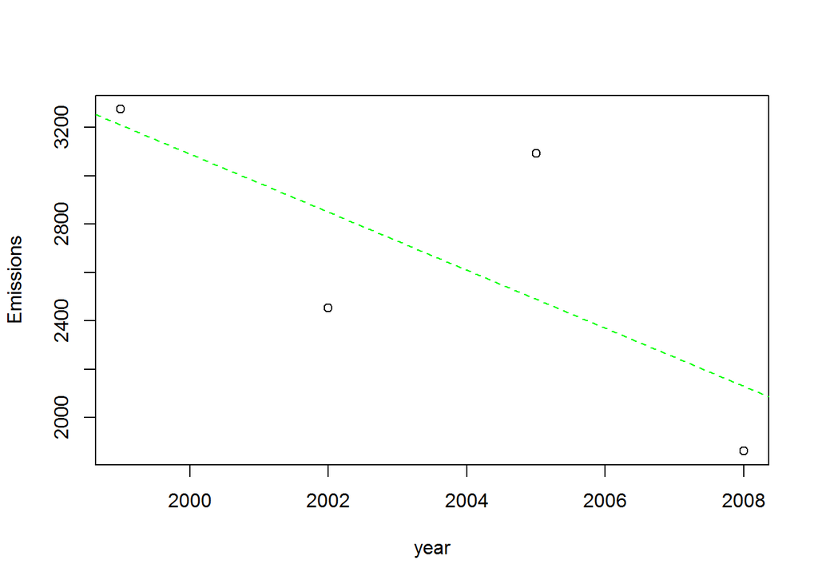

```r
# extract the Baltimore subset. we will use it in later questions
pm25.balt <- subset(NEI, NEI$fips == '24510')
pm25.balt.agg <- aggregate(Emissions ~ year, data=pm25.balt, FUN=sum)
plot(Emissions ~ year, data=pm25.balt.agg)
# regression line
pm25.balt.regr <- lm(Emissions ~ year, pm25.balt.agg)
# width=1, dotted, green
abline(pm25.balt.regr, lwd=1, lty=2, col='green')
```

### 3. Of the four types of sources indicated by the type (point, nonpoint, onroad, nonroad) variable, which of these four sources have seen decreases in emissions from 1999–2008 for Baltimore City? Which have seen increases in emissions from 1999–2008?

Use the ggplot2 plotting system to make a plot answer this question.

```r
# using dplyr for easier manipulation
library(dplyr)
dt.balt <- tbl_df(pm25.balt)

# grouping the dataset by type and by year and adding all Emissions in an *emissions* column
dt.balt.bytype <- dt.balt %>% group_by(type, year) %>% summarize(emissions=sum(Emissions)) %>% print
```

```
## Source: local data frame [16 x 3]
## Groups: type [?]
##
##        type  year  emissions
##       (chr) (int)      (dbl)
## 1  NON-ROAD  1999  522.94000
## 2  NON-ROAD  2002  240.84692
## 3  NON-ROAD  2005  248.93369
## 4  NON-ROAD  2008   55.82356
## 5  NONPOINT  1999 2107.62500
## 6  NONPOINT  2002 1509.50000
## 7  NONPOINT  2005 1509.50000
## 8  NONPOINT  2008 1373.20731
## 9   ON-ROAD  1999  346.82000
## 10  ON-ROAD  2002  134.30882
## 11  ON-ROAD  2005  130.43038
## 12  ON-ROAD  2008   88.27546
## 13    POINT  1999  296.79500
## 14    POINT  2002  569.26000
## 15    POINT  2005 1202.49000
## 16    POINT  2008  344.97518
```

```
## geom_smooth: method="auto" and size of largest group is <1000, so using loess. Use 'method = x' to change the smoothing method.
```

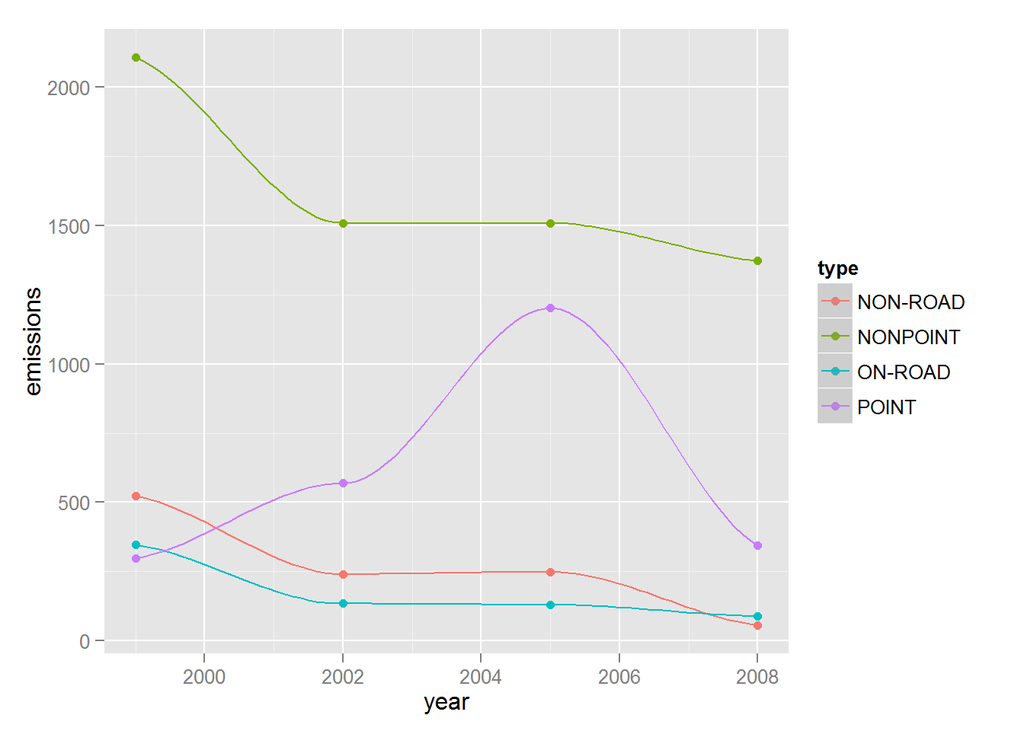

```r
library(ggplot2)
plot3 <- qplot(year, emissions, data=dt.balt.bytype, color=type, geom = c('point', 'smooth'))
suppressWarnings(print(plot3))
```

### 4. Across the United States, how have emissions from coal combustion-related sources changed from 1999–2008?

The sectors are in the form of “Fuel Comb - Electric Generation - Coal”: **coal** seems to be spelled-out, while **combustion** is shortened to **comb**..

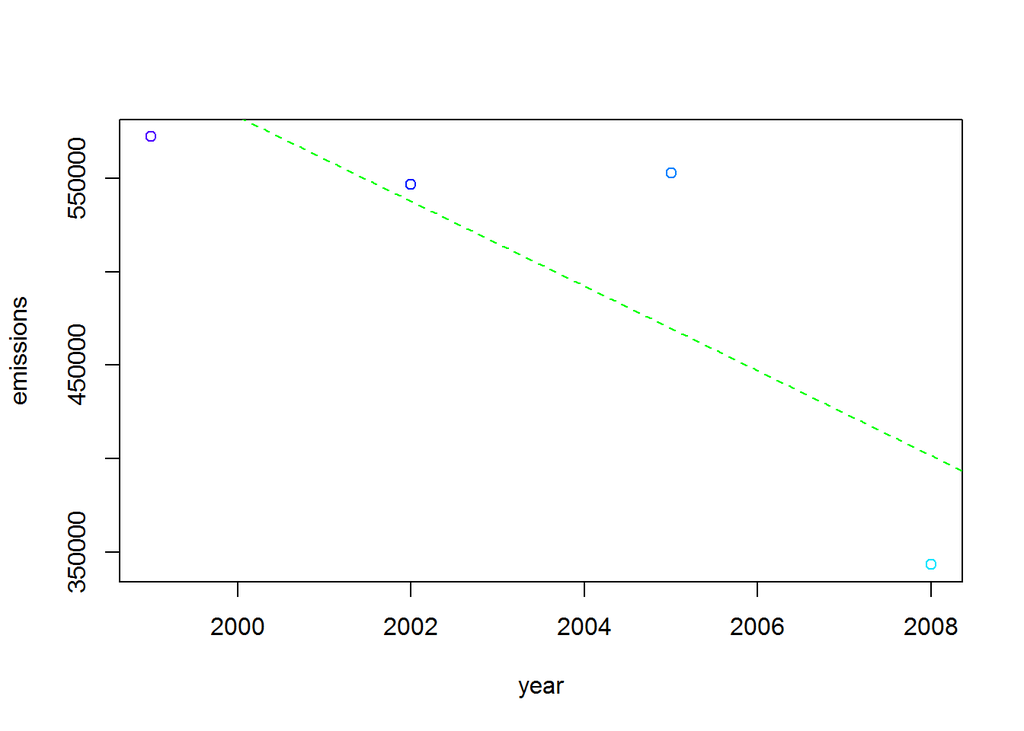

```r
# searching for sectors containing both "coal" and "comb" aka combustion
# and accounting only for those that have both
coco <- intersect(grep('Coal', SCC$EI.Sector), grep('Comb', SCC$EI.Sector))
# SCC contains the codes in the NEI$SCC column
coco.codes <- SCC[coco, 'SCC']
# now lets use dplyr to summarize those sources by year
coco.sum <- NEI %>% filter(SCC %in% coco.codes) %>% group_by(year) %>% summarize(emissions=sum(Emissions))
# to be able to compare with the plot in question 1, we'll use the same plot call
plot(emissions ~ year, data=coco.sum, col=topo.colors(8))
abline(lm(emissions ~ year, data=coco.sum), lwd=1, lty=2, col='green')
```

### 5. How have emissions from motor vehicle sources changed from 1999–2008 in Baltimore City?

The codebook at http://www3.epa.gov/ttn/chief/net/2008neiv3/2008_neiv3_tsd_draft.pdf, page 112, section **4.6 On-road - all Diesel and Gasoline Vehicles**, lists the following EIS sectors:

- Mobile – On-road – Diesel Heavy Duty Vehicles
- Mobile – On-road – Diesel Light Duty Vehicles
- Mobile – On-road – Gasoline Heavy Duty Vehicles
- Mobile – On-road – Gasoline Light Duty Vehicles

```r
# use grep to find Diesel or Gasoline, Light or Heavy Duty Vehicles in the EI.Sector
moto.codes <- SCC[grep('On-Road (Diesel|Gasoline) (Heavy|Light) Duty Vehicles', SCC$EI.Sector), "SCC"]
# we have the `dt.balt` dplyr tbl from Question 3, representing all emissions measurements in Baltimore.
# Let's use it.
moto.sum.balt <- dt.balt %>% filter(SCC %in% moto.codes) %>% group_by(year) %>% summarize(emissions=sum(Emissions)) %>% print
```

```
## Source: local data frame [4 x 2]
##
##    year emissions
##   (int)     (dbl)
## 1  1999 346.82000
## 2  2002 134.30882
## 3  2005 130.43038
## 4  2008  88.27546
```

```
## geom_smooth: method="auto" and size of largest group is <1000, so using loess. Use 'method = x' to change the smoothing method.
```

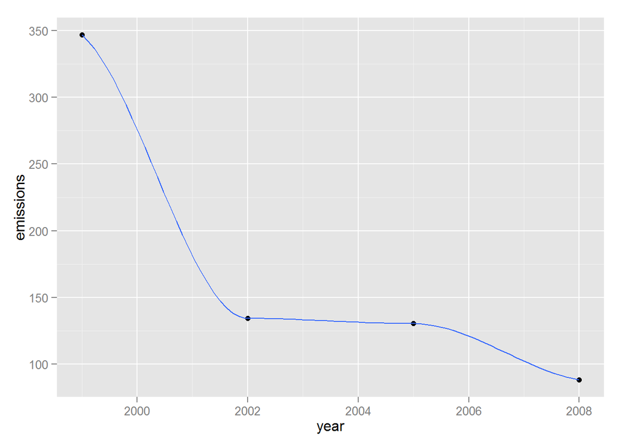

```r
# since we used ggplot for Question 3, let's use the same.
plot5 <- qplot(year, emissions, data=moto.sum.balt, geom=c('point', 'smooth'))
suppressWarnings(print(plot5))
```

### 6. Compare emissions from motor vehicle sources in Baltimore City with emissions from motor vehicle sources in Los Angeles County, California (fips == “06037”).

Which city has seen greater changes over time in motor vehicle emissions?

```
## geom_smooth: method="auto" and size of largest group is <1000, so using loess. Use 'method = x' to change the smoothing method.
```

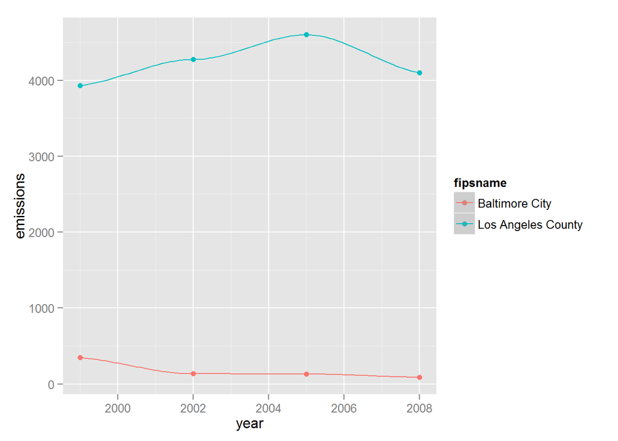

```r
# we already have the aggregate data for Baltimore in moto.sum.balt from Question 5
# let's perform the same aggregate for LA now
dt.la <- tbl_df(NEI[NEI$fips == '06037',])
moto.sum.la <- dt.la %>% filter(SCC %in% moto.codes) %>% group_by(year) %>% summarize(emissions=sum(Emissions))
# to plot them both on the same chart, let's mutate them and add a column with the city/county aka fipsname
moto.sum.balt <- mutate(moto.sum.balt, fipsname='Baltimore City')
moto.sum.la <- mutate(moto.sum.la, fipsname='Los Angeles County')
# now let's union the two so we can plot them together
moto.sum.bla <- union(moto.sum.balt, moto.sum.la)
plot6 <- qplot(year, emissions, data=moto.sum.bla, color=fipsname, geom=c('point', 'smooth'))
suppressWarnings(print(plot6))
```